# analysis

DBIAT

Saturday, May 30, 2015

# Data Analyses for the Emotion and Recall YouTube Experiment

## INTRODUCTION

This analysis was created to explain the data analysis behind the [Emotion and Recall YouTube Experiment](https://www.youtube.com/watch?v=iphxvoAOpE4). All the materials–the videos, informed consent, etc.–can be found at the above link. NOTE BENE: the link–and the videos–do not work properly on Apple products that do not contain Flash support, nor do they work in many smartphones (which, likewise, often do not have Flash support). Following the links is best done on a PC.

Although there were quite a number of variables included in the raw data, only the variables valence, arousal, and number of correct responses were analyzed, as they dealt specifically with the primary hypotheses. It is these three variables which are included in the presentation and poster.

## DATA PREPARATION

First, the data needed to be ‘read’ by rStudio…

```r
affect<-read.csv("affect.csv")
```

Next, there was the need to change ‘subject’ into a factor…

```r
affect$subject<-factor(affect$subject)
```

Check the structure to see if the change took…

```r
str(affect)
```

```
## 'data.frame':    43 obs. of  11 variables:
##  $ subject  : Factor w/ 43 levels "1","2","3","4",..: 1 2 3 4 5 6 7 8 9 10 ...
##  $ affect   : Factor w/ 4 levels "NH","NL","PH",..: 2 2 4 4 2 4 4 1 1 4 ...
##  $ condition: int  1 1 2 2 1 2 2 3 3 2 ...
##  $ valence  : Factor w/ 2 levels "negative","positive": 1 1 2 2 1 2 2 1 1 2 ...
##  $ arousal  : Factor w/ 2 levels "high","low": 2 2 2 2 2 2 2 1 1 2 ...
##  $ total    : int  20 20 20 20 20 20 20 20 20 20 ...
##  $ thought  : int  3 6 9 8 11 10 10 4 13 11 ...
##  $ correct  : int  2 3 8 8 11 9 10 2 6 10 ...
##  $ sex      : Factor w/ 2 levels "female","male": 2 1 2 2 2 1 1 1 1 2 ...
##  $ age      : int  29 45 55 37 45 34 26 21 53 43 ...
##  $ student  : Factor w/ 2 levels "n","y": 1 1 1 1 1 1 1 1 1 1 ...
```

## PRIMARY ANALYSES

The variable of interest is memory as measured by word recall.

There are two factors being studied (valence/arousal). Each factor has two levels: Valence (negative/positive) and Arousal (high/low)

There are three null hypotheses to be tested: H01: Both valence groups have, on the average, equal word recall. H02: Both arousal groups have, on the average, equal word recall. H03: The two factors-valence and arousal-are independent.

Since we have multiple factors and levels, we need to use a two-way between-subjects ANOVA.

What we’re looking for is to see whether or not we can predict the number of correctly recalled words from valence and arousal, utilizing first the comprehensive dataset (affect.csv):

```r
summary(aov(correct~valence*arousal,data=affect))
```

```
##                 Df Sum Sq Mean Sq F value Pr(>F)
## valence          1   18.8  18.791   2.282  0.139
## arousal          1    0.0   0.009   0.001  0.973
## valence:arousal  1    0.0   0.008   0.001  0.975
## Residuals       39  321.1   8.233
```

From the results of the combined dataset, F(1,39)=2.28, p=0.14 and F(1,39)=0.001, p=0.97, we can conclude that the number of correctly recalled words is not associated with valence or arousal. Additionally, at F(1,39)=0.001, p=.98, there were no interactions between valence and arousal. The data failed to reject the null.

However, there appeared to be an interesting pattern I discerned as I did a cursory check through the data: it appeared as if those who took the experiment for extra credit–irrespective of valence or arousal level–reported less recalled words. This led me to probe deeper…

```r
affect2<-read.csv("affect2.csv")
```

Once again, there is the need to change ‘subject’ into a factor…

```r
affect2$subject<-factor(affect2$subject)
```

Check the structure to see if the change took…

```r
str(affect2)
```

```
## 'data.frame':    21 obs. of  11 variables:
##  $ subject  : Factor w/ 21 levels "1","2","3","4",..: 1 2 3 4 5 6 7 8 9 10 ...
##  $ affect   : Factor w/ 4 levels "NH","NL","PH",..: 2 2 4 4 2 4 4 1 1 4 ...
##  $ condition: int  1 1 2 2 1 2 2 3 3 2 ...
##  $ valence  : Factor w/ 2 levels "negative","positive": 1 1 2 2 1 2 2 1 1 2 ...
##  $ arousal  : Factor w/ 2 levels "high","low": 2 2 2 2 2 2 2 1 1 2 ...
##  $ total    : int  20 20 20 20 20 20 20 20 20 20 ...
##  $ thought  : int  3 6 9 8 11 10 10 4 13 11 ...
##  $ correct  : int  2 3 8 8 11 9 10 2 6 10 ...
##  $ sex      : Factor w/ 2 levels "female","male": 2 1 2 2 2 1 1 1 1 2 ...
##  $ age      : int  29 45 55 37 45 34 26 21 53 43 ...
##  $ student  : Factor w/ 1 level "n": 1 1 1 1 1 1 1 1 1 1 ...
```

Now let’s run the two-way between-subjects ANOVA once more…

```r
summary(aov(correct~valence*arousal,data=affect2))
```

```
##                 Df Sum Sq Mean Sq F value Pr(>F)
## valence          1  33.59   33.59   3.525 0.0777 .
## arousal          1   2.26    2.26   0.237 0.6325
## valence:arousal  1   0.00    0.00   0.000 0.9947
## Residuals       17 161.96    9.53
## ---
## Signif. codes:  0 '***' 0.001 '**' 0.01 '*' 0.05 '.' 0.1 ' ' 1
```

In this non-student dataset, at F(1,17)=3.53, p=0.08, we still find that the number of correctly recalled words does not rise to statistical significance when associated with valence…but it’s close and is noteworthy. At F(1,17)=0.24, p=0.63, the number of correctly recalled words were also not significantly associated with the level of arousal. Additionally, at F(1,17)=0.00, p=0.99, there were no interactions between valence and arousal.

```r
summary(aov(correct~student*valence*arousal,data=affect))
```

```
##                         Df Sum Sq Mean Sq F value Pr(>F)
## student                  1  37.14   37.14   5.172 0.0292 *
## valence                  1  17.45   17.45   2.429 0.1281
## arousal                  1   0.47    0.47   0.065 0.8006
## student:valence          1  17.37   17.37   2.418 0.1289
## student:arousal          1  11.89   11.89   1.656 0.2067
## valence:arousal          1   2.07    2.07   0.288 0.5952
## student:valence:arousal  1   2.17    2.17   0.302 0.5859
## Residuals               35 251.36    7.18
## ---
## Signif. codes:  0 '***' 0.001 '**' 0.01 '*' 0.05 '.' 0.1 ' ' 1
```

This analysis clearly shows, at F(1,35)=5.172, p=0.03, that the number of correctly recalled words was significantly associated with student status and that no other significant interactions were observed.

Next, we’ll do a t-test to help confirm the different results we’ve found between student and non-student.

```r
t.test(affect$correct[affect$student=="y"],affect$correct[affect$student=="n"])
```

```
##
##  Welch Two Sample t-test
##
## data:  affect$correct[affect$student == "y"] and affect$correct[affect$student == "n"]
## t = -2.2252, df = 35.976, p-value = 0.03242
## alternative hypothesis: true difference in means is not equal to 0
## 95 percent confidence interval:
##  -3.5539279 -0.1646868
## sample estimates:
## mean of x mean of y
##  5.045455  6.904762
```

Indeed, with t(35.98)=-2.23, p=0.03, we find that there was a significant difference in the number of correctly recalled words between students and non-students.

Now for a bar graph…

```r
library("dplyr")
```

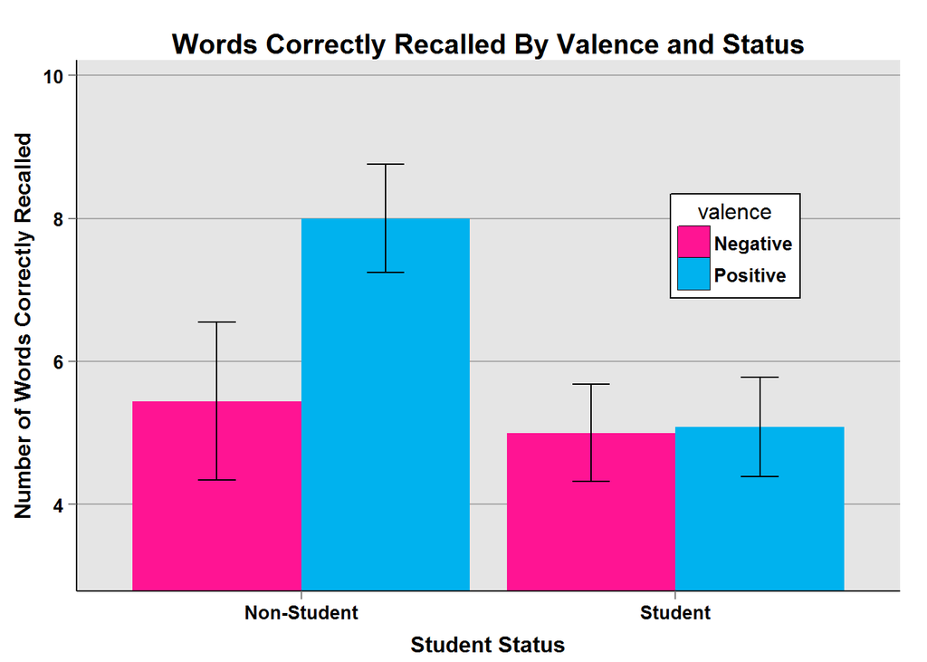

```r
temp<-affect%>%group_by(student,valence)%>%summarize(means=mean(correct),
              sems=sd(correct)/sqrt(length(correct)))
library("ggplot2")
library("gplots")
col1=col2hex("deeppink")
col2=col2hex("deepskyblue2")
f<-ggplot(temp, aes(x=student, y=means, fill=valence))+
    geom_bar(stat="identity",position=position_dodge())+
    scale_fill_manual(values=c(col1,col2),name="valence",breaks=c("negative","positive"),labels=c("Negative", "Positive"))+
    theme(legend.key=element_rect(color="black"))+
    geom_errorbar(aes(ymax=means+sems, ymin=means-sems),width=.2,position=position_dodge(.9))+
    ggtitle("Words Correctly Recalled By Valence and Status")+
    labs(x="Student Status",y="Number of Words Correctly Recalled")+
    scale_x_discrete(breaks=c("n","y"),labels=c("Non-Student","Student"))+
    theme(plot.title=element_text(size=15,face="bold",vjust=.5))+
    theme(axis.title.x=element_text(size=12,face="bold",vjust=-.25))+
    theme(axis.title.y=element_text(size=12,face="bold",vjust=1))+
    theme(axis.text.x=element_text(size=10,face="bold",color="black"))+
    theme(axis.text.y=element_text(size=10,face="bold",color="black"))+
    coord_cartesian(ylim=c(min(temp$means)-2*max(temp$sems),max(temp$means)+2*max(temp$sems)))+
    theme(panel.border=element_blank(),axis.line=element_line())+
    theme(panel.grid.major.x=element_blank())+
    theme(panel.grid.major.y=element_line(color="darkgrey"))+
    theme(panel.grid.minor.y=element_blank())+
    theme(legend.position=c(.80,.65))+
    theme(legend.background=element_blank())+
    theme(legend.background=element_rect(color="black"))+
    theme(legend.title=element_blank())+
    theme(legend.title=element_text(size=12))+
    theme(legend.title.align=.5)+
    theme(legend.text=element_text(size=10,face="bold"))
f
```

I’ll need this for my presentation, so I’ll save it…

```r
ggsave(filename="fig1.png",width=15,height=15, units="cm",dpi=300)
```

## SUPPLEMENTARY ANALYSES

The following analysis was done to ascertain whether or not valence and/or arousal interacted with the number of responses the participants gave, irrespective of whether or not they were correct (listed as “thought” factor in both datasets).

First, using the combined dataset…

```r
summary(aov(thought~valence*arousal,data=affect))
```

```
##                 Df Sum Sq Mean Sq F value Pr(>F)
## valence          1    0.0   0.001   0.000  0.993
## arousal          1    3.4   3.443   0.341  0.562
## valence:arousal  1    1.1   1.122   0.111  0.740
## Residuals       39  393.3  10.084
```

No significant interactions.

Now, let’s check the non-student (“affect2”) dataset…

```r
summary(aov(thought~valence*arousal,data=affect2))
```

```
##                 Df Sum Sq Mean Sq F value Pr(>F)
## valence          1   3.34   3.337   0.332  0.572
## arousal          1   5.26   5.256   0.523  0.479
## valence:arousal  1   5.69   5.693   0.566  0.462
## Residuals       17 170.86  10.050
```

No significant interactions here, either.

## SUMMARY

Although YouTube appears to be a viable platform for experimental and quasi-experimental use, there are limitations this study brought out, most notably, the potential for student status to be a factor in end-results. However, given the proper instructions and, more importantly, participant fidelity to them, there is no reason why YouTube experimentation and quasi-experimentation could not be expanded for certain studies.